# Cleaning

Kaushik Mohan

11/14/2018

```r
load(file="../data/pre_cleaning_sales_data.RData")
```

```r
commercial_condos <- c("RA","RB","RG","RH","RK","RP","RS","RP","RW","R5")
sales_data <- sales_data[!(sales_data$building_class_at_time_of_sale %in% commercial_condos),]
N <- dim(sales_data)[1]
```

```r
sales_data$BldgArea <- as.numeric(sales_data$BldgArea)
sales_data$ResArea <- as.numeric(sales_data$ResArea)
```

## Datasets

1. NYC Annualized Property Sales Data (2012-2017)
2. MapPLUTO (18v1)
3. Geoclient API v1.1

## Merging Process

1. Subset building classes A,B,C,D,R,S as these are the ones coming under the residential tax class
2. Merge with MapPLUTO data on `Borough`,`Block` and `Lot`
3. Condo listings don’t merge as there is a mismatch in BBL with MapPLUTO data. Therefore, we use Geoclient API to get the `condominiumBillingBbl` for the condos and then merge with MapPLUTO data on the `BBL`.

## Cleaning Data

### 1. Sale Price

First, we analyse the distribution of the sale prices. We note a sharp peak at 1, which is a price of $\$10$. Also, from the overall distribution, we observe a lot of spikes below $\$10,000$ (red line). Hence, we choose to remove all the cases where the Price is less than $\$10,000$.

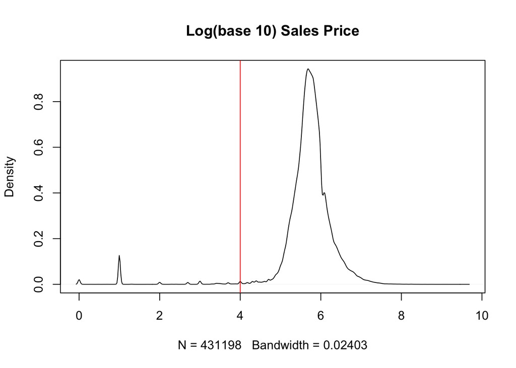

```r
plot(density(log10(sales_data$sale_price)),main="Log(base 10) Sales Price")
abline(v=log10(10000),col=2)
```

```r
s2 <- sales_data %>% filter(sale_price <= 10000)
table(sales_data$building_class)
```

```
##
##      A      B      C      D      R      S
## 100280  87132  66717  84444  80378  12247
```

```r
table(s2$building_class)
```

```
##
##     A     B     C     D     R     S
## 33240 34545 24778  9178     5  5783
```

```r
sales_data <- sales_data %>% filter(sale_price > 10000)
N_prev <- (1-(dim(sales_data)[1]/N))*100
paste0(round((1-(dim(sales_data)[1]/N))*100,2),"% rows removed")
```

```
## [1] "24.94% rows removed"
```

### 2. Area

We need the are of the building because we would calculate the price per sq. ft which is a better measure than the sale price itself.

We have `Gross Sq. Ft` in the Property Sales Data and Building Floor Area (`BldgArea`) Residential Floor Area (`ResArea`) in the MapPLUTO Data. We note that `Gross Sq. Ft` strongly associated and predicted by with both these with a slope of nearly 1, except for the cases when the `Gross Sq. Ft` is 0, of course. Given `Bldg Area` has way fewer missing values, we choose to predict the missing values in `Gross Sq. Ft` with the using the `Bldg Area` from MapPLUTO data based on the simple linear model we fit on the non-missing ones.

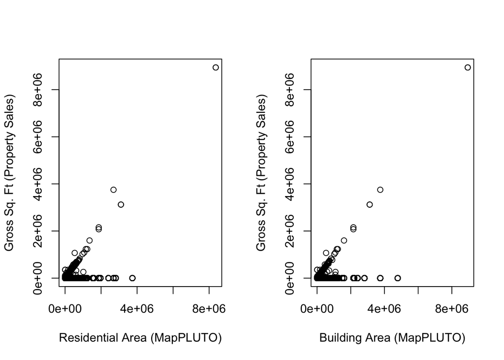

```r
par(mfrow=c(1,2))
plot(y=sales_data$gross_square_feet,x=sales_data$ResArea,
     ylab="Gross Sq. Ft (Property Sales)",
     xlab="Residential Area (MapPLUTO)")

plot(y=sales_data$gross_square_feet,x=sales_data$BldgArea,
     ylab="Gross Sq. Ft (Property Sales)",
     xlab="Building Area (MapPLUTO)")
```

```r
# plot(y=sales_data$gross_square_feet[sales_data$building_class == "A"],x=sales_data$BldgArea[sales_data$building_class == "A"],
#      ylab="Gross Sq. Ft (Property Sales)",
#      xlab="Building Area (MapPLUTO)",xlim=c(0,15000))
#
#
# plot(y=sales_data$gross_square_feet[sales_data$building_class == "B"],x=sales_data$BldgArea[sales_data$building_class == "B"],
#      ylab="Gross Sq. Ft (Property Sales)",
#      xlab="Building Area (MapPLUTO)",xlim=c(0,3e4))
#
#
# plot(y=sales_data$gross_square_feet[sales_data$building_class == "C"],x=sales_data$BldgArea[sales_data$building_class == "C"],
#      ylab="Gross Sq. Ft (Property Sales)",
#      xlab="Building Area (MapPLUTO)",xlim=c(0,0.5e6))
#
# plot(y=sales_data$gross_square_feet[sales_data$building_class == "D"],x=sales_data$BldgArea[sales_data$building_class == "D"],
#      ylab="Gross Sq. Ft (Property Sales)",
#      xlab="Building Area (MapPLUTO)",xlim=c(0,4e6))
#
# plot(y=sales_data$gross_square_feet[sales_data$building_class == "R"],x=sales_data$BldgArea[sales_data$building_class == "R"],
#      ylab="Gross Sq. Ft (Property Sales)",
#      xlab="Building Area (MapPLUTO)",xlim=c(0,4e5))
#
# plot(y=sales_data$gross_square_feet[sales_data$building_class == "S"],x=sales_data$BldgArea[sales_data$building_class == "S"],
#      ylab="Gross Sq. Ft (Property Sales)",
#      xlab="Building Area (MapPLUTO)",xlim=c(0,20000))
```

```r
get_subset_data <- function(sales_data,bclass,xlim){
    s <- sales_data %>% filter(BldgArea > 100 & BldgArea < xlim & building_class == bclass & gross_square_feet > 100)
    return(s[,c("gross_square_feet","BldgArea","Borough" ,"building_class")])
}

s.A <- get_subset_data(sales_data,"A",15000)
s.B <- get_subset_data(sales_data,"B",3e4)
s.C <- get_subset_data(sales_data,"C",0.5e6)
s.D <- get_subset_data(sales_data,"D",4e6)
s.R <- get_subset_data(sales_data,"R",3e5)
s.S <- get_subset_data(sales_data,"S",20000)

fitting_subset <- rbind(s.A,s.B,s.C,s.D,s.R,s.S)
```

```r
f2 <- lm(gross_square_feet ~ 0 + BldgArea + building_class + building_class*BldgArea + Borough,data=fitting_subset)
summary(f2)
```

```
##
## Call:
## lm(formula = gross_square_feet ~ 0 + BldgArea + building_class +
##     building_class * BldgArea + Borough, data = fitting_subset)
##
## Residuals:
##     Min      1Q  Median      3Q     Max
## -394944    -164     -51     121  534704
##
## Coefficients:
##                            Estimate Std. Error t value Pr(>|t|)
## BldgArea                  7.732e-01  1.235e-02  62.625  < 2e-16 ***
## building_classA           3.763e+02  2.617e+01  14.381  < 2e-16 ***
## building_classB           1.136e+03  3.035e+01  37.421  < 2e-16 ***
## building_classC           3.325e+02  1.956e+01  17.001  < 2e-16 ***
## building_classD          -1.455e+02  6.633e+01  -2.193  0.02831 *
## building_classR           3.998e+04  5.399e+02  74.044  < 2e-16 ***
## building_classS           5.584e+02  7.270e+01   7.681 1.59e-14 ***
## BoroughBX                 1.446e+02  2.289e+01   6.317 2.67e-10 ***
## BoroughMN                 1.836e+02  3.878e+01   4.735 2.20e-06 ***
## BoroughQN                -4.870e+01  1.642e+01  -2.966  0.00302 **
## BoroughSI                 5.598e+01  2.137e+01   2.619  0.00881 **
## BldgArea:building_classB -2.788e-01  1.701e-02 -16.389  < 2e-16 ***
## BldgArea:building_classC  1.632e-01  1.242e-02  13.136  < 2e-16 ***
## BldgArea:building_classD  2.270e-01  1.235e-02  18.380  < 2e-16 ***
## BldgArea:building_classR -4.821e-01  1.314e-02 -36.679  < 2e-16 ***
## BldgArea:building_classS  4.546e-02  2.131e-02   2.133  0.03295 *
## ---
## Signif. codes:  0 '***' 0.001 '**' 0.01 '*' 0.05 '.' 0.1 ' ' 1
##
## Residual standard error: 2534 on 153065 degrees of freedom
## Multiple R-squared:  0.9884, Adjusted R-squared:  0.9884
## F-statistic: 8.13e+05 on 16 and 153065 DF,  p-value: < 2.2e-16
```

```r
sales_data <- sales_data %>%
  mutate(area = gross_square_feet )

# plot(density(predict(f2, newdata=sales_data[sales_data$area == 0,])))

sales_data$area[sales_data$area == 0] <- predict(f2,
                                                 newdata = sales_data[sales_data$area == 0,c("BldgArea","Borough" ,"building_class")])

# table(sales_data$building_class[sales_data$area <= 0])
```

### 3. Filtering by area

We see a few cases with area less than 100 sq.ft (red line). We remove these.

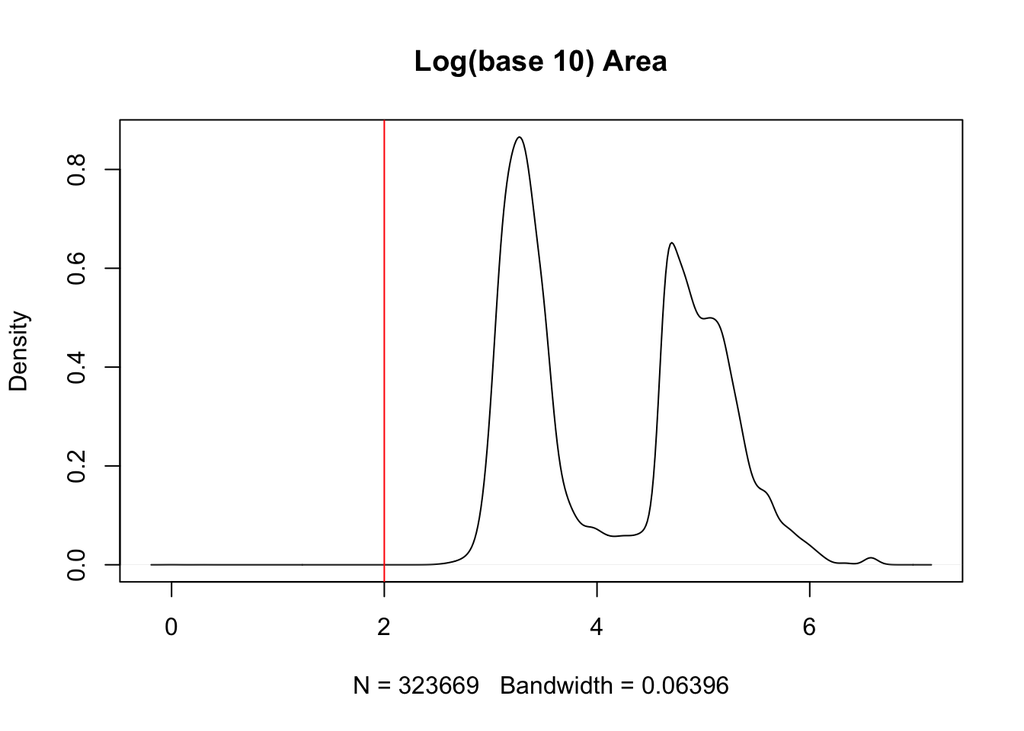

```r
plot(density(log10(sales_data$area)),"Log(base 10) Area")
abline(v=log10(100),col=2)
```

```r
sales_data <- sales_data %>% filter(area > 100)
paste0(round((1-(dim(sales_data)[1]/N))*100 - N_prev,3),"% rows removed")
```

```
## [1] "0.003% rows removed"
```

```r
N_prev <- (1-(dim(sales_data)[1]/N))*100
```

### 4. Price per sq. ft

```r
sales_data$price_per_sqft <- sales_data$sale_price/sales_data$area
```

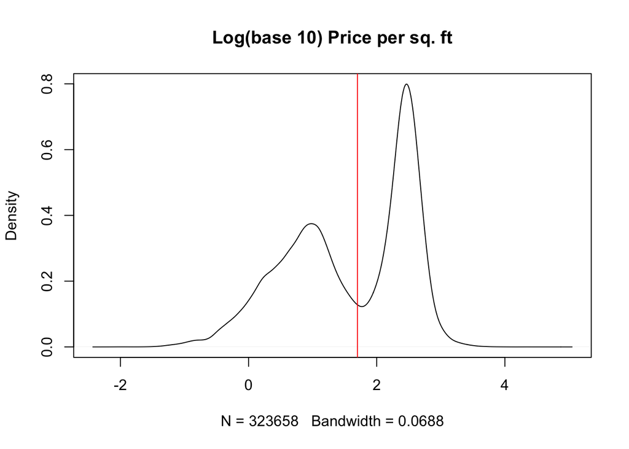

```r
plot(density(log10(sales_data$price_per_sqft)),main="Log(base 10) Price per sq. ft")
abline(v=log10(50),col=2)
```

Majority of the ones with prices lower than $\$50$ per sq. ft are Condos and Co-ops (Class R and D respectively). This seems highly odd as we would expect these to be the most expensive.

```r
s2 <- sales_data$building_class[sales_data$price_per_sqft <= 50]
table(sales_data$building_class)
```

```
##
##     A     B     C     D     R     S
## 67036 52585 41934 75266 80373  6464
```

```r
table(s2)
```

```
## s2
##     A     B     C     D     R     S
##   785  1061 12492 71705 75147   233
```

```r
# sales_data <- sales_data %>% filter(price_per_sqft > 50)
# paste0(round((1-(dim(sales_data)[1]/N))*100 - N_prev,2),"% rows removed")
# N_prev <- (1-(dim(sales_data)[1]/N))*100
```

#### 4.1 Checking Price Distributions

Below are the marginals by Borough and Building class and distributions of price per square feet by building class. It is a bit odd that Condo (Building Class R) and Coop Apartment (Building Class D) prices have a very different distribution compared to the rest. Also, the scale is completely off with respect to price estimates for New York City. Zillow suggests the Median price per sq. ft of a condo in Manhattan is closer to $1800.

```r
sales_data %>% group_by(Borough) %>%
  summarise(median_price_per_sqft = median(price_per_sqft))
```

| Borough | median_price_per_sqft |
| --- | --- |
| BK | 141.6367 |
| BX | 137.7557 |
| MN | 11.5031 |
| QN | 192.9488 |
| SI | 243.3768 |

```r
sales_data %>% group_by(building_class) %>%
  summarise(median_price_per_sqft = median(price_per_sqft))
```

| building_class | median_price_per_sqft |
| --- | --- |
| A | 317.884730 |
| B | 268.233876 |
| C | 148.133122 |
| D | 2.957973 |
| R | 10.898160 |
| S | 258.630506 |

```r
sales_data %>% group_by(Borough,building_class) %>%
  summarise(median_price_per_sqft = median(price_per_sqft))
```

| Borough | building_class | median_price_per_sqft |
| --- | --- | --- |
| BK | A | 385.3383459 |
| BK | B | 302.1978022 |
| BK | C | 204.0221683 |
| BK | D | 2.4845737 |
| BK | R | 12.2184852 |
| BK | S | 268.3615819 |
| BX | A | 235.8222556 |
| BX | B | 188.2534495 |
| BX | C | 138.3333333 |
| BX | D | 1.3977551 |

[output cut: 20 more lines]

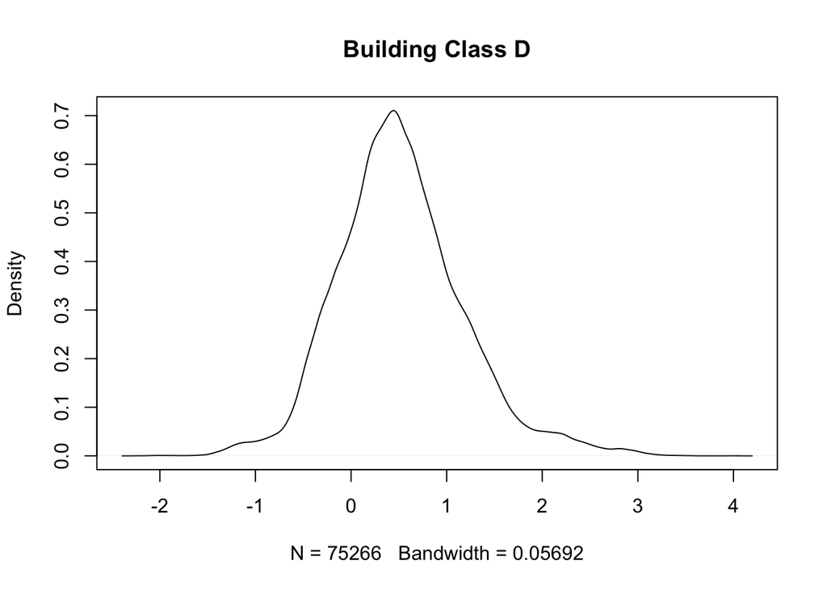

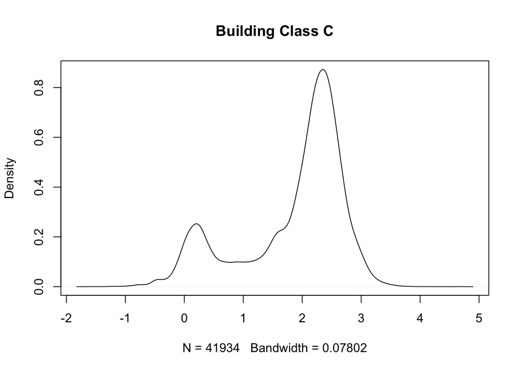

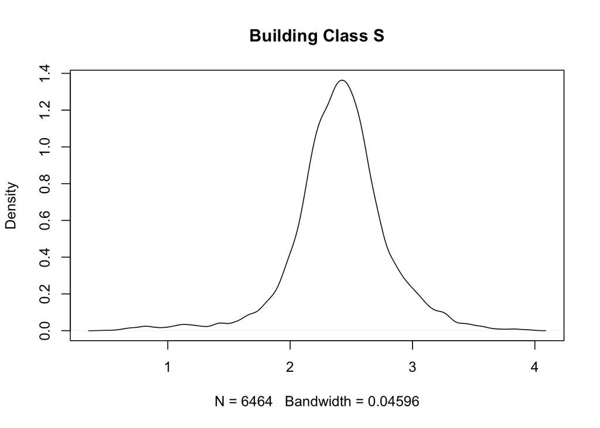

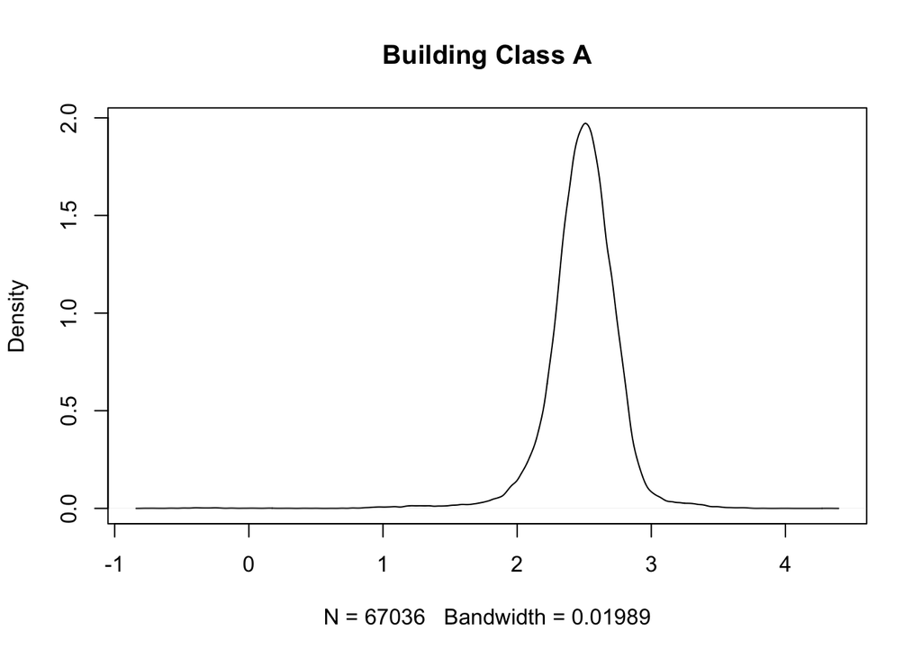

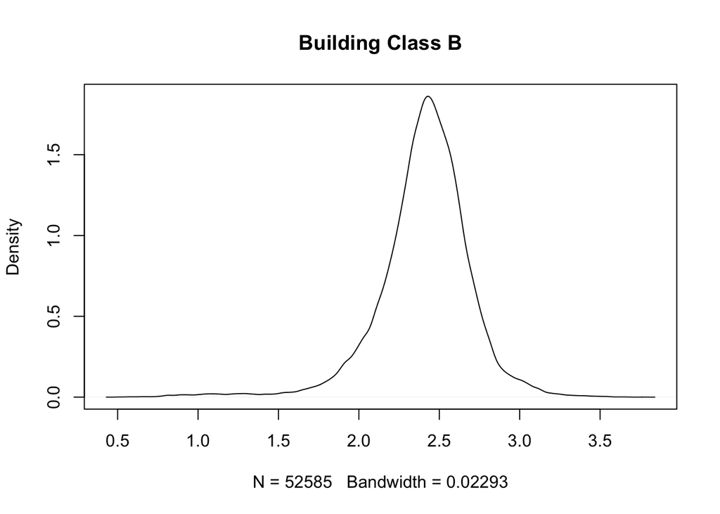

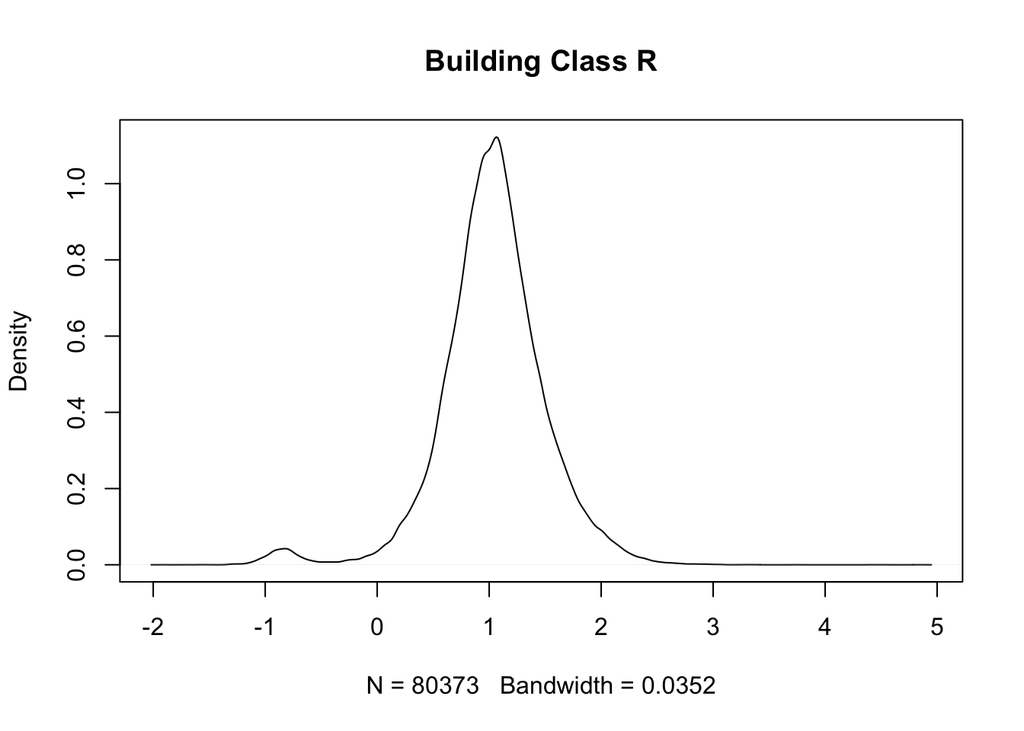

```r
uq <- unique(sales_data$building_class)
for(i in seq_along(unique(sales_data$building_class))){
  plot(density(log10(sales_data$price_per_sqft[sales_data$building_class == uq[i]])),main=paste0("Building Class ",uq[i]))
}
```

```r
sales_data$adj_ppsf <- sales_data$price_per_sqft*sales_data$ResidFAR
```

```r
## Fixing years
sales_data$year[is.na(sales_data$year)] <- year(as.Date(sales_data$sale_date[is.na(sales_data$year)],origin="1900-01-01"))

## adding tract as per census
sales_data$Tract2010 <- str_pad(sales_data$Tract2010,6,side="right",pad="0")
sales_data$boro_ct201 <- paste0(sales_data$borough,sales_data$Tract2010)
```